# Group project_Proteomics_Group22

2025-11-27

# 1. Data exploration

## 1.1 loading in the data

```r
library(tidyverse)
```

```r
library(ComplexHeatmap)
meta <- read.csv("C:/Users/brent/Documents/MASTER1/Group project/feature_meta.csv")
combined <- read.csv("C:/Users/brent/Documents/MASTER1/Group project/combined_dataset.csv")
```

## 1.2 Check the features at the end of the combined dataset

```r
colnames(combined)[(ncol(combined)-17):ncol(combined)]
```

```
##  [1] "IRF6"                          "individual_id"
##  [3] "ethnicity"                     "sex"
##  [5] "calc_age"                      "ihd"
##  [7] "previous_vte"                  "copd"
##  [9] "diabetes"                      "smoking"
## [11] "cause_eskd"                    "WHO_severity"
## [13] "WHO_temp_severity"             "fatal_disease"
## [15] "case_control"                  "radiology_evidence_covid"
## [17] "time_from_first_symptoms"      "time_from_first_positive_swab"
```

```r
#Splitting of the combined dataset
protein_data  <- combined[, 1:(ncol(combined)-16), drop = FALSE]
clinical_data <- combined[, (ncol(combined)-15):ncol(combined), drop = FALSE]
#check

head(clinical_data)
```

```
##   ethnicity sex calc_age      ihd previous_vte copd diabetes     smoking
## 1     asian   M       61 yes.cabg           no   no   yes.T2 not.current
## 2     asian   M       61 yes.cabg           no   no   yes.T2 not.current
## 3     asian   M       61 yes.cabg           no   no   yes.T2 not.current
## 4     asian   M       61 yes.cabg           no   no   yes.T2 not.current
## 5     asian   M       61 yes.cabg           no   no   yes.T2 not.current
## 6     asian   M       61 yes.cabg           no   no   yes.T2 not.current
##            cause_eskd WHO_severity WHO_temp_severity fatal_disease case_control
## 1 DN (bx or presumed)                       NEGATIVE                   NEGATIVE
## 2 DN (bx or presumed)       severe          moderate         False     POSITIVE
## 3 DN (bx or presumed)       severe            severe         False     POSITIVE
## 4 DN (bx or presumed)       severe          moderate         False     POSITIVE
## 5 DN (bx or presumed)       severe            severe         False     POSITIVE
## 6 DN (bx or presumed)       severe            severe         False     POSITIVE
##                      radiology_evidence_covid time_from_first_symptoms
## 1                                                                   NA
## 2 yes:extensivebilateralairspaceconsolidation                        7
## 3 yes:extensivebilateralairspaceconsolidation                       10
## 4 yes:extensivebilateralairspaceconsolidation                       12
## 5 yes:extensivebilateralairspaceconsolidation                       14
## 6 yes:extensivebilateralairspaceconsolidation                        0
##   time_from_first_positive_swab
## 1                            NA
## 2                            11
## 3                            14
## 4                            16
## 5                            18
## 6                             4
```

## 1.3 Distribution of the different features in the clinical_data

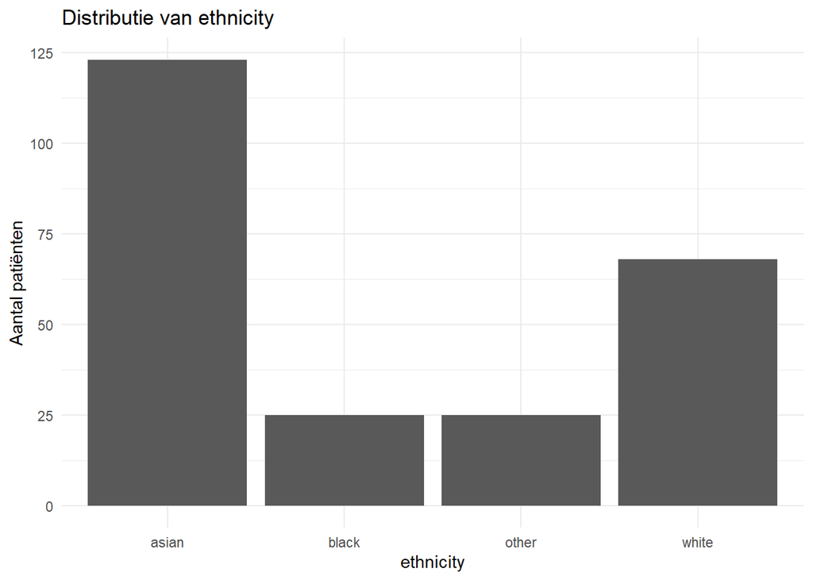

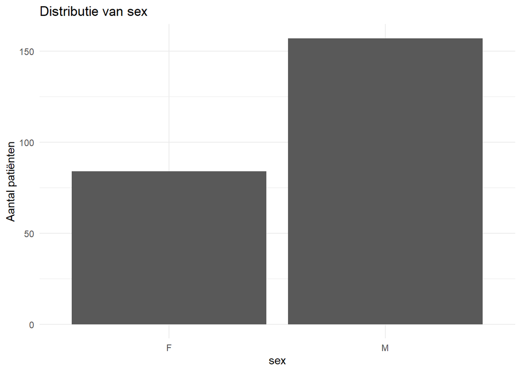

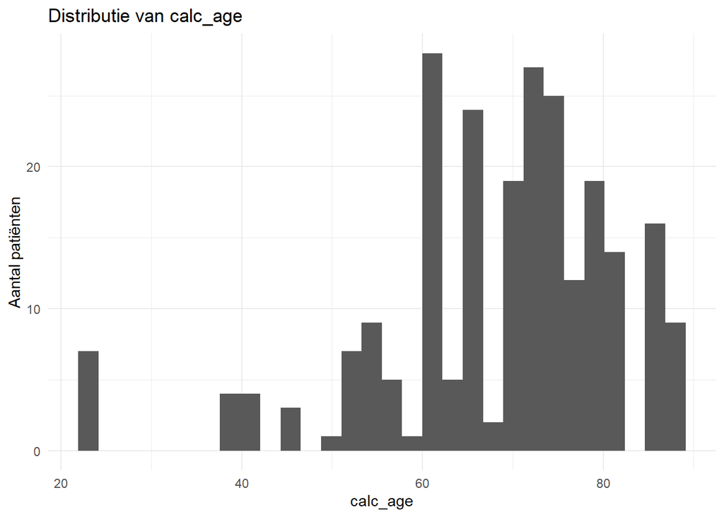

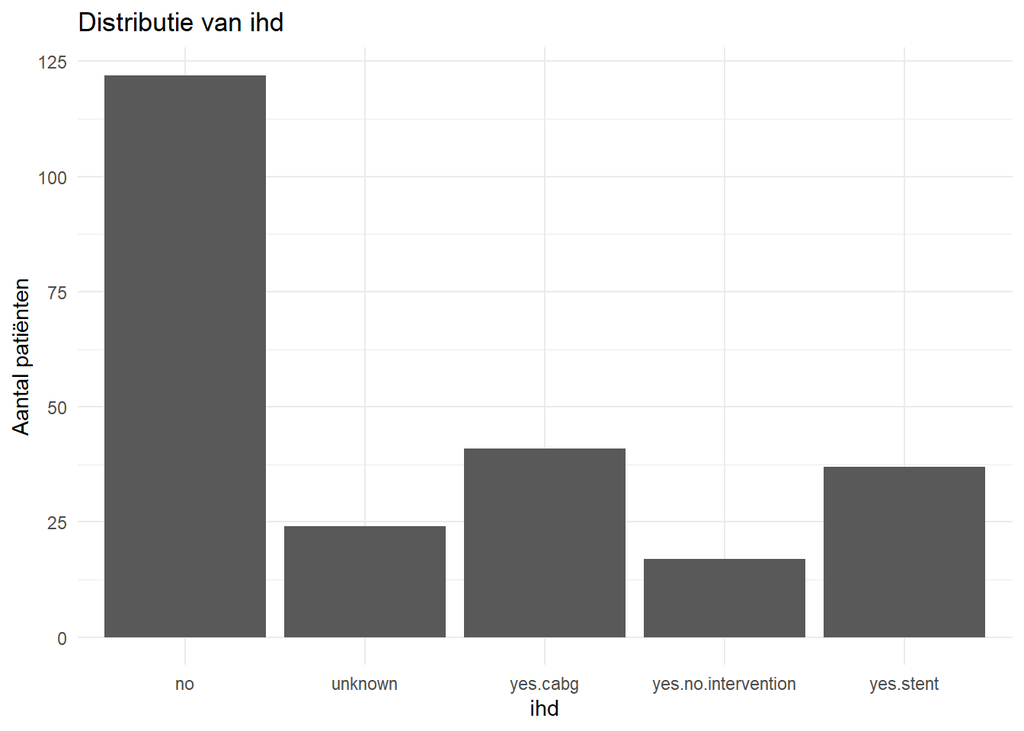

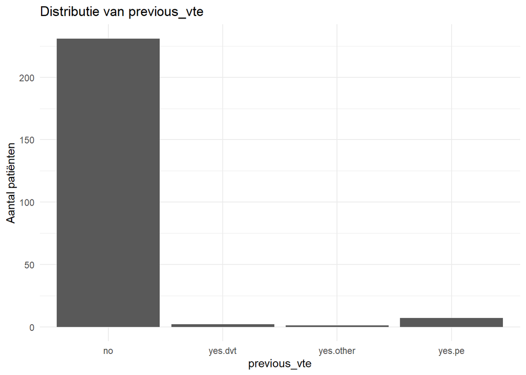

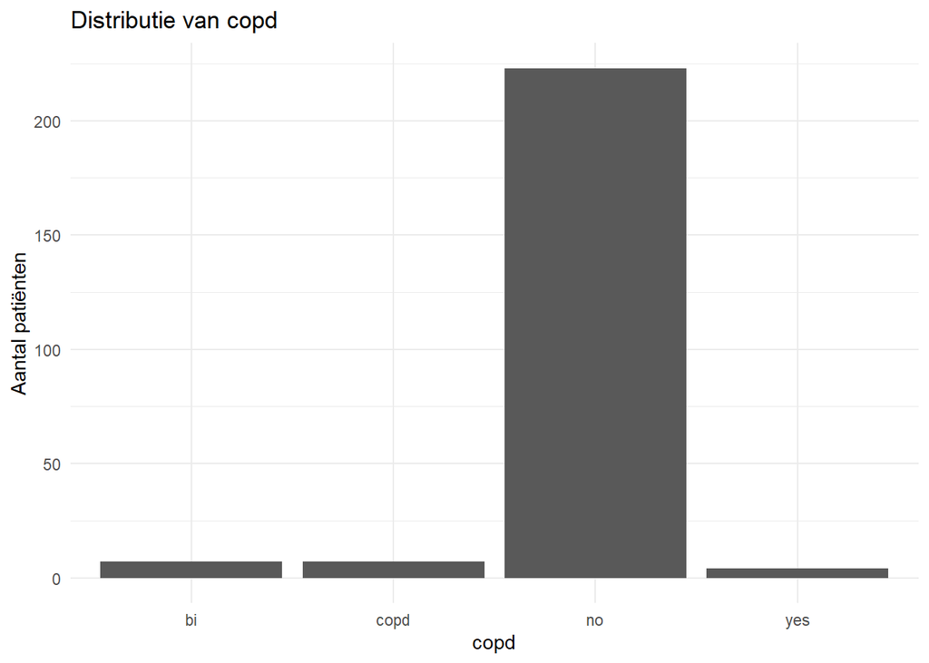

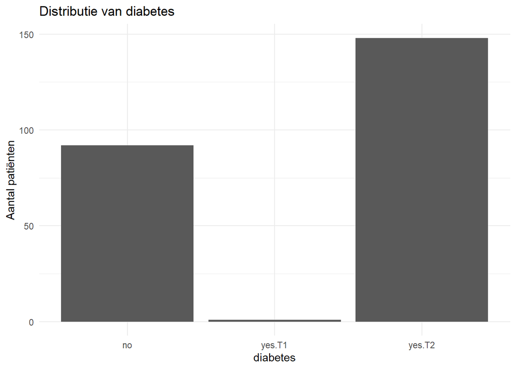

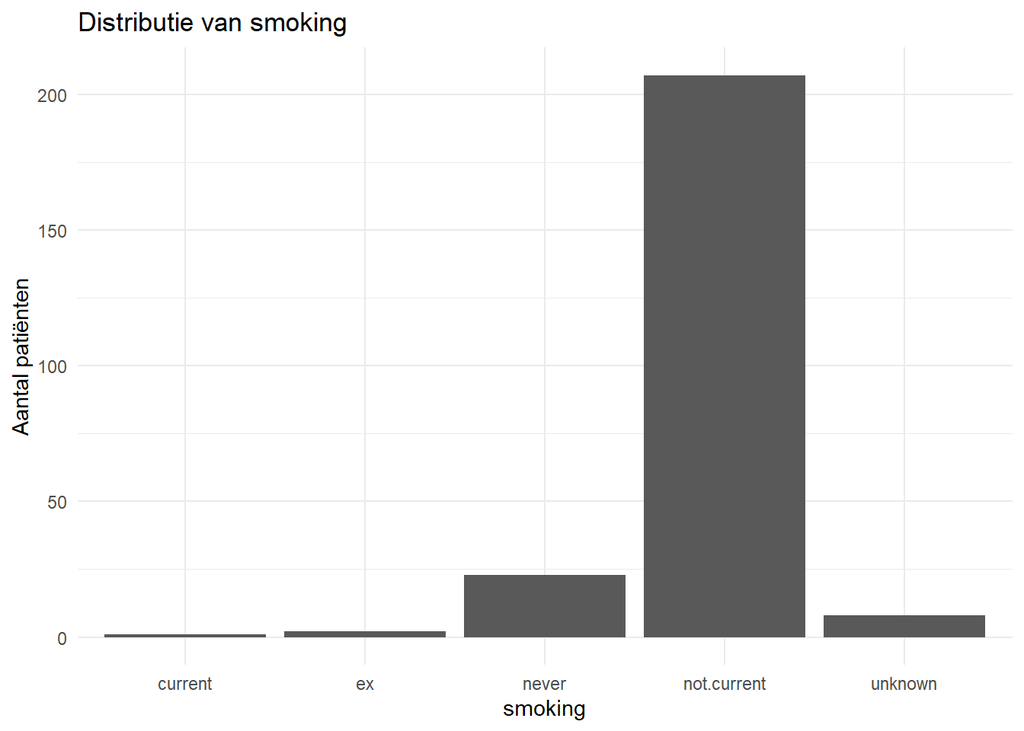

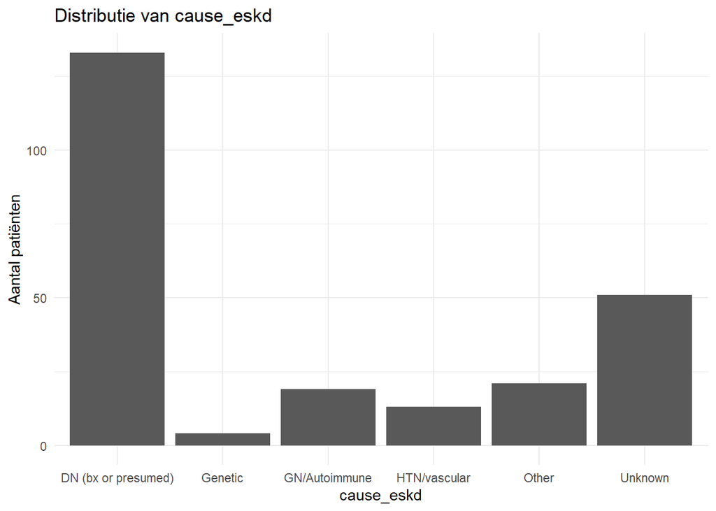

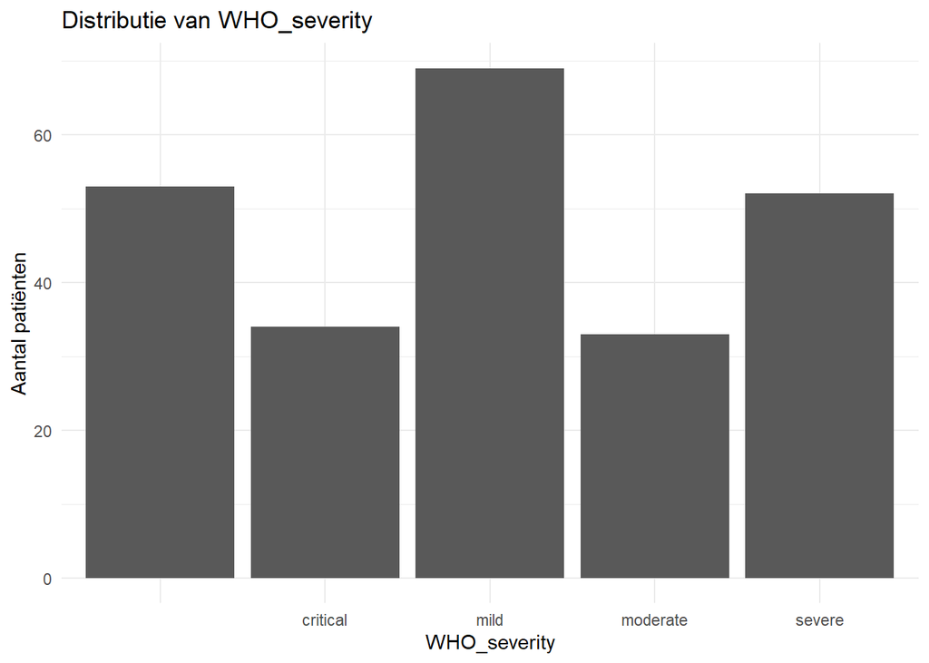

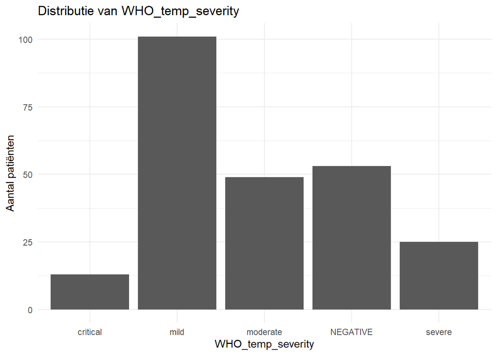

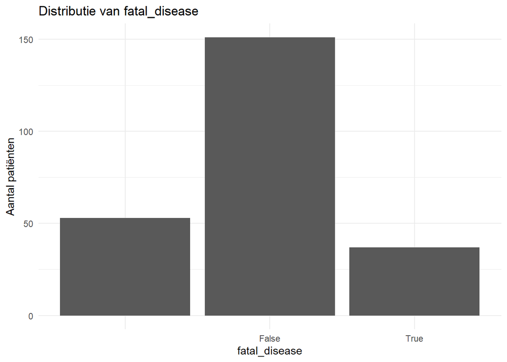

[4 more figures not shown]

```r
# Load  packages
library(tidyverse)

# Run over all columns
for (col in names(clinical_data)) {

  # Extract column
  column_data <- clinical_data[[col]]

  # heck for numeric and categorical data
  if (is.numeric(column_data)) {

    p <- ggplot(clinical_data, aes(x = .data[[col]])) +
      geom_histogram() +
      labs(title = paste("Distributie van", col),
           x = col,
           y = "Aantal patiënten") +
      theme_minimal()

  } else {

    p <- ggplot(clinical_data, aes(x = .data[[col]])) +
      geom_bar() +
      labs(title = paste("Distributie van", col),
           x = col,
           y = "Aantal patiënten") +
      theme_minimal()

  }

  # Show plot
  print(p)
}
```

## 1.4 Looking of the genes of interest are normally distributed

```
## $`1`
```

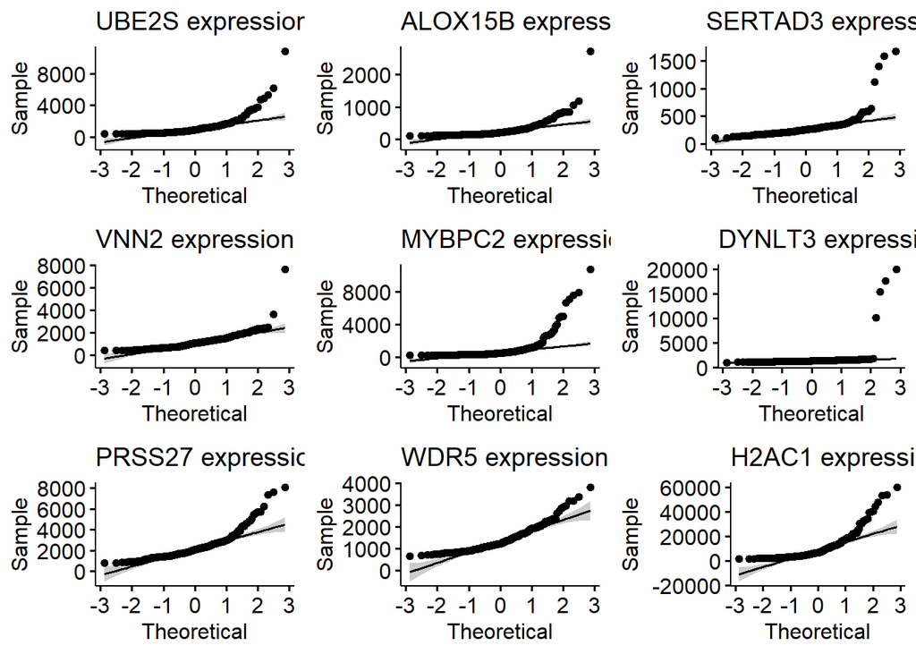

```
##
## $`2`
```

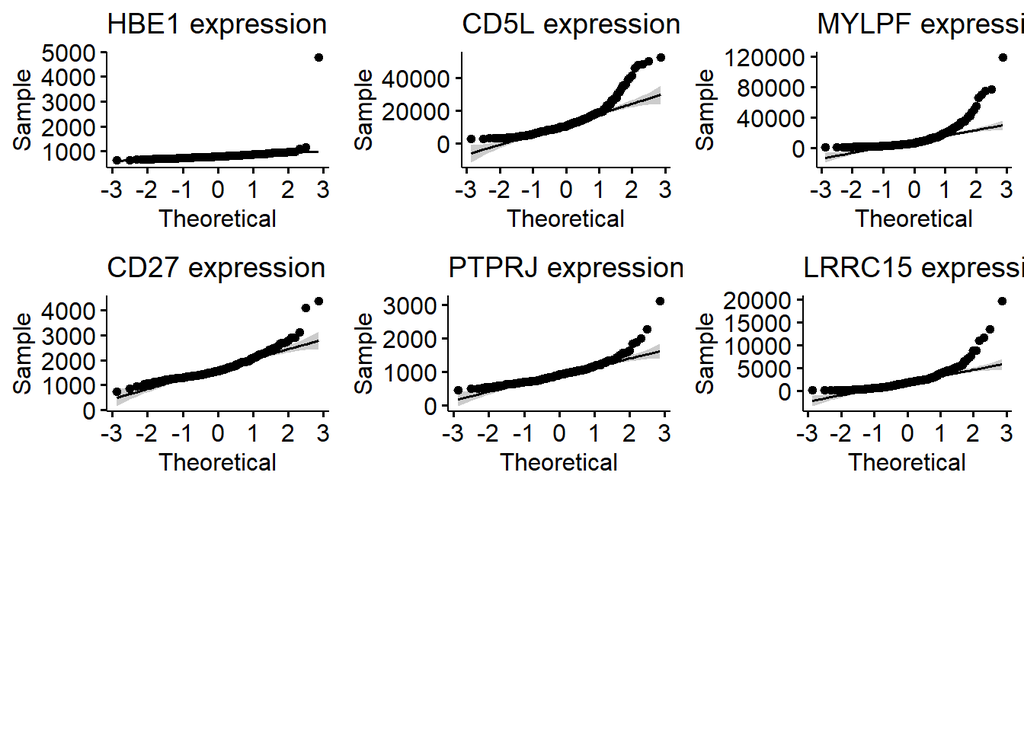

```
##
## attr(,"class")
## [1] "list"      "ggarrange"
```

```r
library(dplyr)
library(ggpubr)

# list of proteins of interest
proteins <- c("UBE2S", "ALOX15B", "SERTAD3", "VNN2", "MYBPC2",

   "DYNLT3", "PRSS27", "WDR5", "H2AC1", "HBE1",

   "CD5L", "MYLPF", "CD27", "PTPRJ", "LRRC15")

# make for every protein a QQ plot
plots <- lapply(proteins, function(p) {
 if (p %in% colnames(combined)) {
   ggqqplot(combined, x = p) +
     ggtitle(paste(p, "expression"))
 } else {
   ggplot() + ggtitle(paste("Column not found:", p))
 }
})

# show every plot
ggpubr::ggarrange(plotlist = plots, ncol = 3, nrow = 3 )
```

We can see that the genes of interests are not normally distributed: Normalisation is needed.

## 1.5 Normalisation: TMM transformation and LOG transformation

```r
library(edgeR)
# 1) make a copy of the data set to do log tranformation
combined_log <- combined

# 2) Determine which columns are the proteins
# column 1 = SampleID
# last 17 columns = clinical data
protein_cols <- 2:(ncol(combined) - 17)

# 3)extract protein matrix and convert to numeric
protein_matrix <- as.matrix(combined[, protein_cols])
protein_matrix <- apply(protein_matrix, 2, function(x) as.numeric(as.character(x)))

# 4) Make DGEList and TMM-normalise
dge <- DGEList(counts = protein_matrix)
dge <- calcNormFactors(dge, method = "TMM")

# 5) retrieve normalalised CPM-values
protein_norm <- cpm(dge, normalized.lib.sizes = TRUE)

# 6) replace de protein-columns in the dataset with TMM-normlalized values
combined_log[, protein_cols] <- protein_norm

# 7) Conduct log2(x+1) transformation
combined_log[, protein_cols] <- lapply(combined_log[, protein_cols], function(x) {
 log2(x + 1)
})
```

Checking whether Normalization has worked

```
## $`1`
```

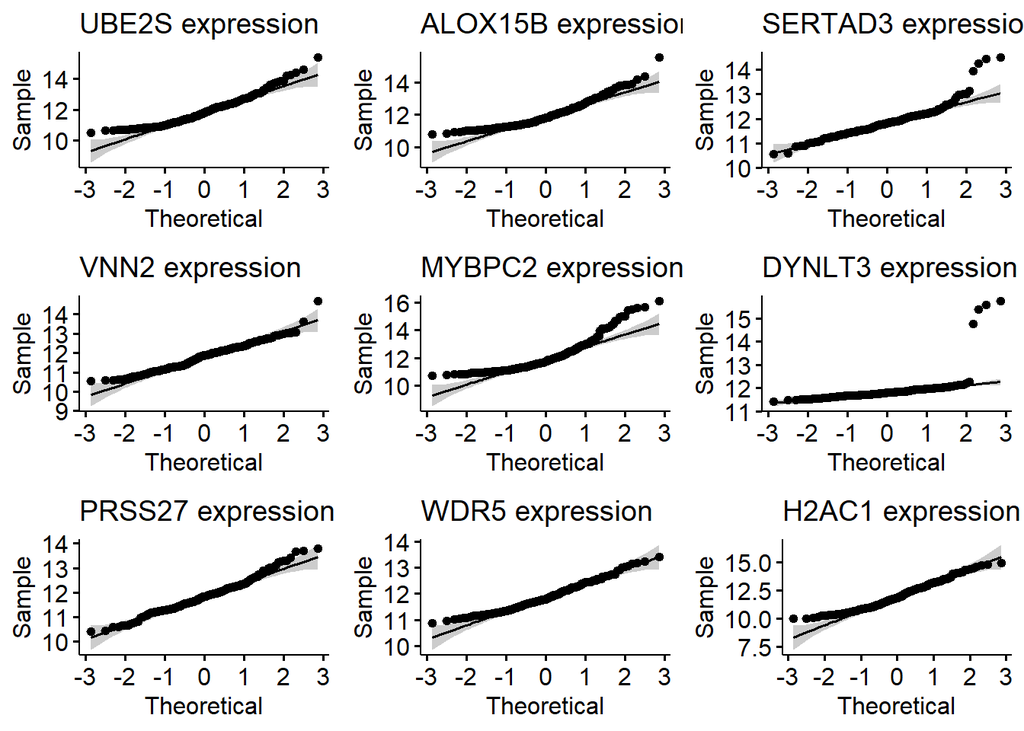

```
##
## $`2`
```

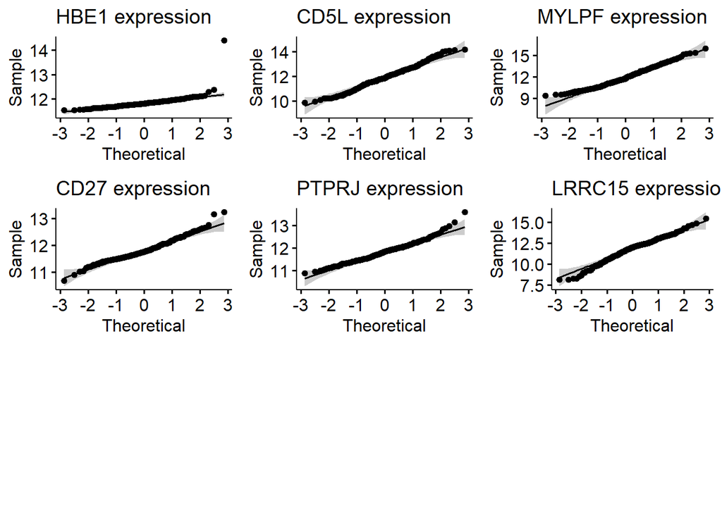

```
##
## attr(,"class")
## [1] "list"      "ggarrange"
```

```r
library(dplyr)
library(ggpubr)

# list proteins of interest
proteins <- c("UBE2S", "ALOX15B", "SERTAD3", "VNN2", "MYBPC2",

   "DYNLT3", "PRSS27", "WDR5", "H2AC1", "HBE1",

   "CD5L", "MYLPF", "CD27", "PTPRJ", "LRRC15")

# make for every protein a QQ plot
plots <- lapply(proteins, function(p) {
 if (p %in% colnames(combined_log)) {
   ggqqplot(combined_log, x = p) +
     ggtitle(paste(p, "expression"))
 } else {
   ggplot() + ggtitle(paste("Column not found:", p))
 }
})

# show plots
ggpubr::ggarrange(plotlist = plots, ncol = 3, nrow = 3)
```

## 1.6 DEA (differntial expression analysis)

### 1.6.1 Heatmap

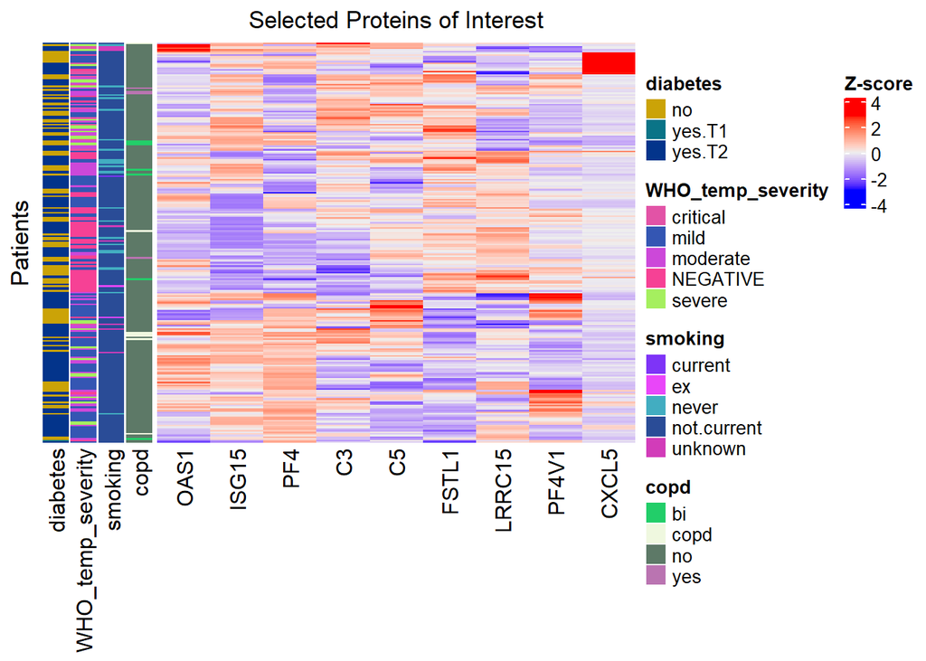

```r
# ----------------------------------------------------
# 0. FIX DUPLICATE PATIENT IDS SAFELY
# ----------------------------------------------------

if("individual_id" %in% colnames(combined_log)){
  ids <- as.character(combined_log$individual_id)
} else {
  ids <- paste0("Patient_", seq_len(nrow(combined_log)))
}

# Replace NAs with a placeholder
ids[is.na(ids)] <- paste0("Patient_NA_", seq_len(sum(is.na(ids))))

# Make IDs unique
ids_unique <- make.unique(ids)

# Add unique ID to dataframe
combined_log$unique_id <- ids_unique

# Set rownames (now guaranteed no NA)
rownames(combined_log) <- combined_log$unique_id

# ----------------------------------------------------
# 1. SPLIT PROTEINS AND CLINICAL DATA
# ----------------------------------------------------

protein_data  <- combined_log[, 1:(ncol(combined_log)-16), drop = FALSE]
clinical_data <- combined_log[, (ncol(combined_log)-15):ncol(combined_log), drop = FALSE]

rownames(protein_data)  <- combined_log$unique_id
rownames(clinical_data) <- combined_log$unique_id
clinical_data <- as.data.frame(clinical_data)

# ----------------------------------------------------
# 2. CLEAN / CONVERT PROTEIN DATA TO NUMERIC
# ----------------------------------------------------

library(dplyr)
protein_data <- protein_data %>%
  mutate(across(everything(), ~ suppressWarnings(as.numeric(as.character(.)))))

# ----------------------------------------------------
# 3. PROTEINS OF INTEREST
# ----------------------------------------------------

proteins_of_interest <- c(
  "LRRC15", "PF4", "PF4V1", "CXCL5", "ALOX12", "FSTL1",
  "H2A", "H2B", "H3", "H4", "C3", "C5",
  "ISG15", "OAS1", "IFITM3"
)

proteins_of_interest <- proteins_of_interest[proteins_of_interest %in% colnames(protein_data)]

# ----------------------------------------------------
# 4. SELECT ONLY YOUR PROTEINS
# ----------------------------------------------------

selected_proteins <- proteins_of_interest
heatmap_data <- protein_data[, selected_proteins, drop = FALSE]

# ----------------------------------------------------
# 5. SCALE (Z-SCORE)
# ----------------------------------------------------

heatmap_scaled <- scale(heatmap_data)

# ----------------------------------------------------
# 6. CLINICAL ROW ANNOTATIONS
# ----------------------------------------------------

annotation_vars <- c("diabetes", "WHO_temp_severity", "smoking", "copd")
annotation_vars <- annotation_vars[annotation_vars %in% colnames(clinical_data)]

annotation_df <- clinical_data %>%
  select(all_of(annotation_vars)) %>%
  mutate(across(everything(), as.factor))

rownames(annotation_df) <- combined_log$unique_id
annotation_df <- annotation_df[rownames(heatmap_scaled), , drop = FALSE]

library(ComplexHeatmap)
row_ha <- rowAnnotation(df = annotation_df)

# ----------------------------------------------------
# 7. FINAL HEATMAP (WITH ROW ANNOTATIONS)
# ----------------------------------------------------

Heatmap(
  heatmap_scaled,
  name = "Z-score",
  cluster_rows = TRUE,
  cluster_columns = TRUE,
  show_row_names = FALSE,
  show_column_names = TRUE,
  left_annotation = row_ha,
  column_title = "Selected Proteins of Interest",
  row_title = "Patients",
  show_row_dend = FALSE,
  show_column_dend = FALSE
)
```

#1.6.2 PCA Plot of Protein Expression by WHO COVID-19 Severity

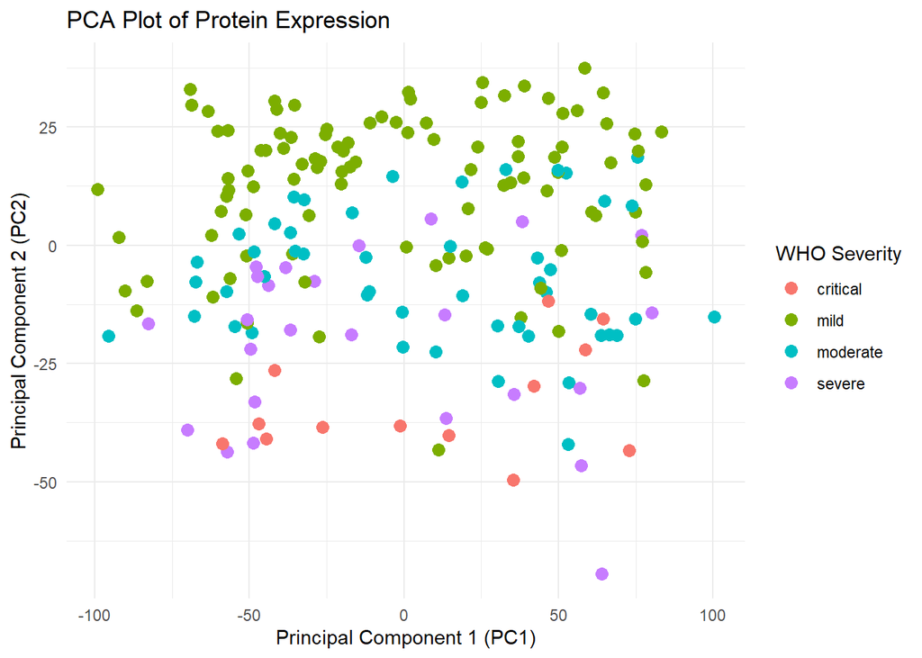

```r
# Load required libraries
library(edgeR)
library(ggplot2)

# 1. Select only protein columns
# (First column is an ID, last 16 columns are clinical features)
protein_cols <- 2:(ncol(combined_log) - 16)
protein_data <- combined_log[, protein_cols]

# 2. Convert all values to numeric
protein_data <- as.data.frame(lapply(protein_data, as.numeric))
# 3. Remove columns that are constant or contain only NA values
# Keep only columns that have at least 2 unique non-NA values
protein_data <- protein_data[, colSums(is.na(protein_data)) < nrow(protein_data)]
protein_data <- protein_data[, apply(protein_data, 2, function(x) length(unique(x[!is.na(x)])) > 1)]

# 4. Remove "NEGATIVE" samples from the clinical severity column
# Filter both protein data and severity labels
filtered_idx <- combined_log$WHO_temp_severity != "NEGATIVE"
protein_data <- protein_data[filtered_idx, ]
severity <- combined_log$WHO_temp_severity[filtered_idx]

# 5. Run PCA
pca <- prcomp(protein_data, center = TRUE, scale. = TRUE)

# 6. Prepare dataframe for plotting and generate PCA plot
pca_df <- data.frame(pca$x[, 1:2], Severity = severity)

ggplot(pca_df, aes(x = PC1, y = PC2, color = Severity)) +
  geom_point(size = 3) +
  labs(
    title = "PCA Plot of Protein Expression",
    x = "Principal Component 1 (PC1)",
    y = "Principal Component 2 (PC2)",
    color = "WHO Severity"
  ) +
  theme_minimal()
```

#1.6.3 Volcano plots where the pairwise comparisons are made of the different severity groups

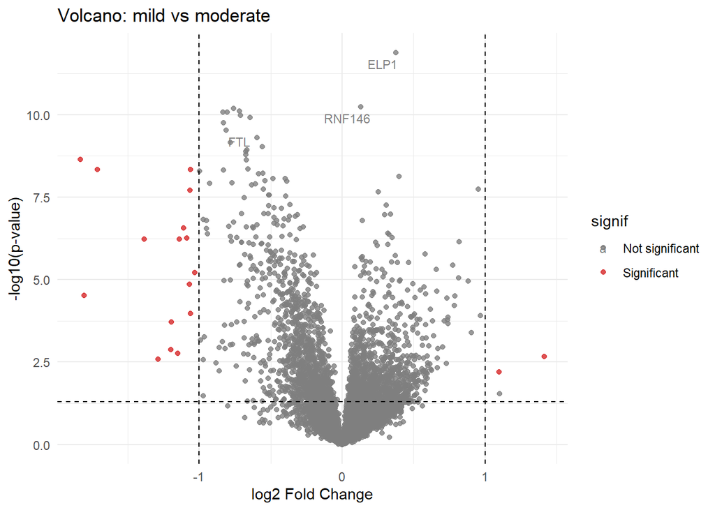

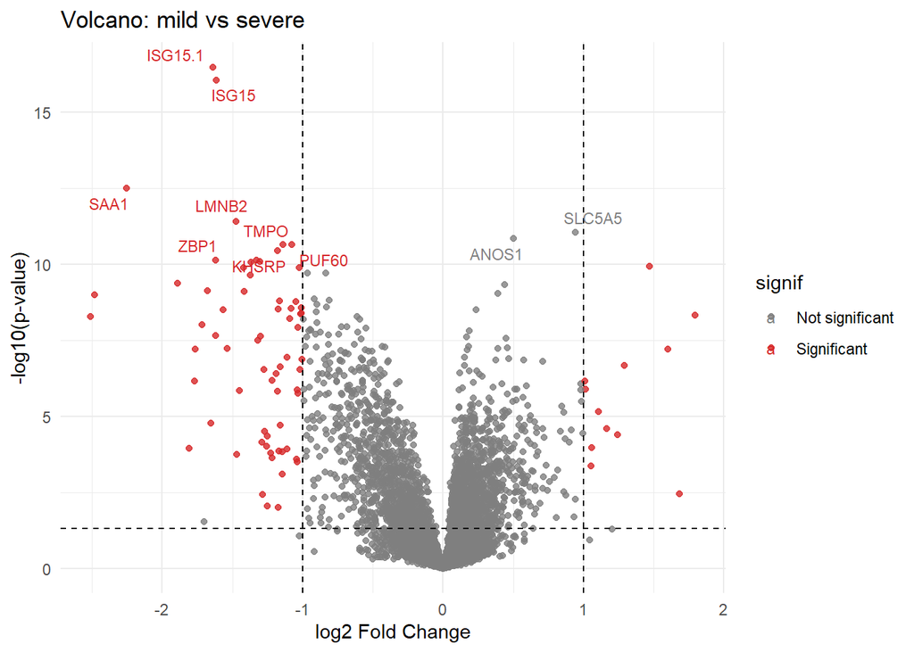

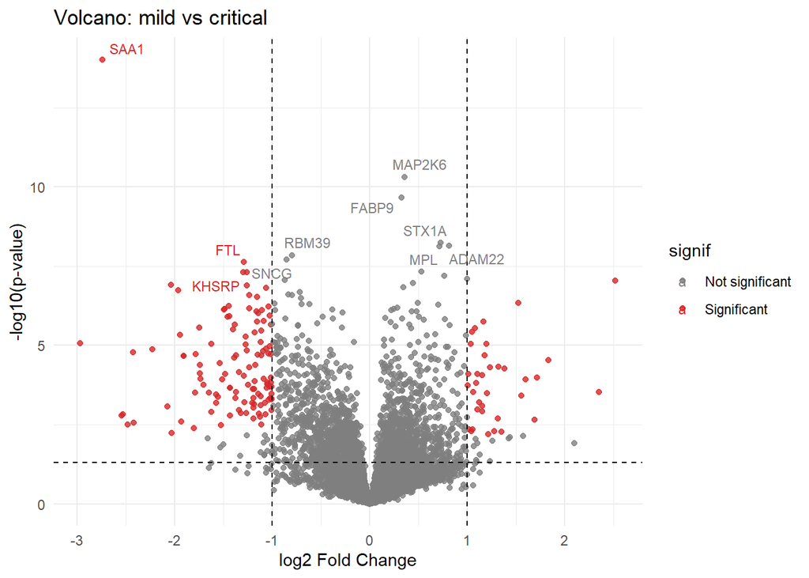

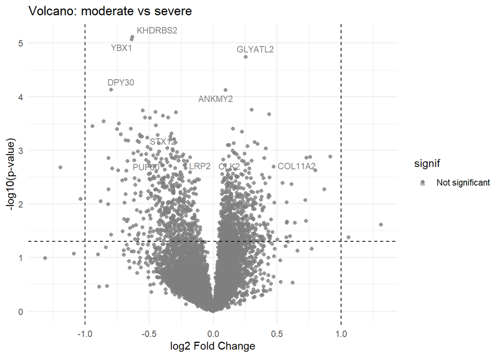

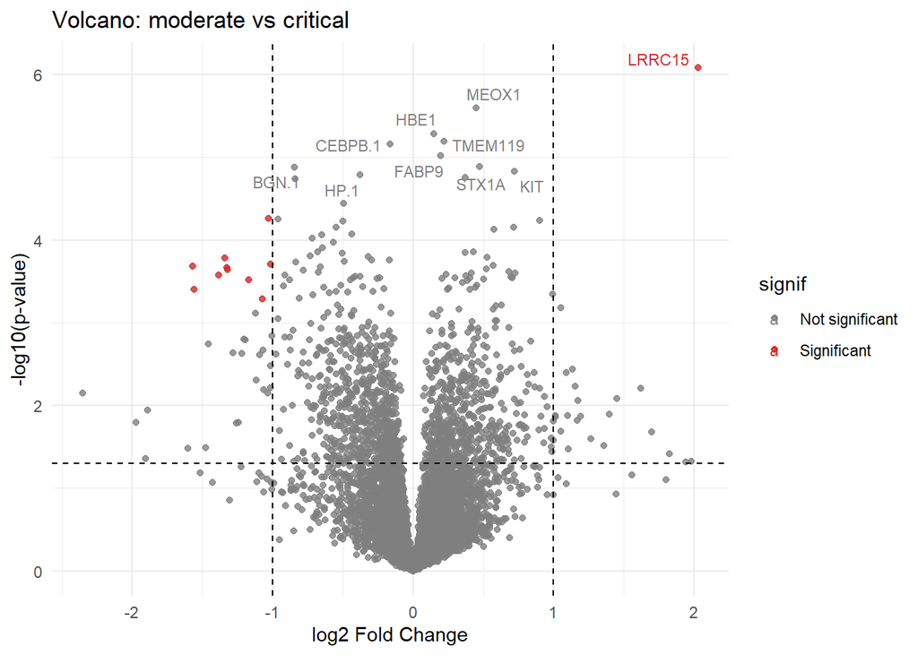

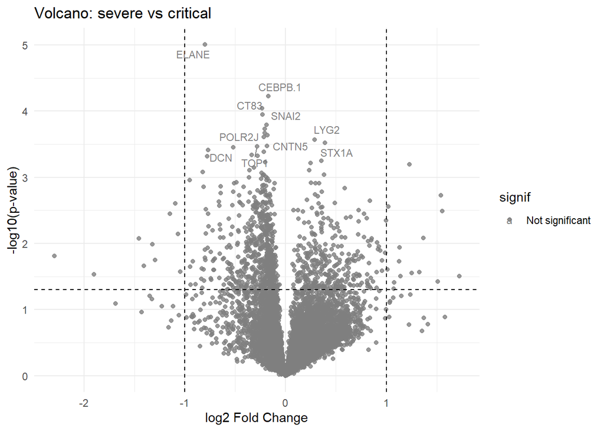

```r
library(dplyr)
library(ggplot2)
library(ggrepel)
library(purrr)

# 1. Filter NEGATIVE and set severity levels
df <- combined_log %>%
filter(WHO_temp_severity != "NEGATIVE") %>%
mutate(WHO_temp_severity = factor(WHO_temp_severity,
                                  levels = c("mild","moderate","severe","critical")))

# 2. Select protein columns
protein_cols <- 2:(ncol(df) - 16)
protein_data <- as.data.frame(lapply(df[, protein_cols], function(x) suppressWarnings(as.numeric(x))))

# drop columns who are completely NA or have no variation
protein_data <- protein_data[, colSums(is.na(protein_data)) < nrow(protein_data)]
protein_data <- protein_data[, apply(protein_data, 2, function(x) length(unique(x[!is.na(x)])) > 1)]

group <- df$WHO_temp_severity

# 3.  Functions for LogFC and P-value
safe_t_p <- function(x, g1_idx, g2_idx) {
x1 <- x[g1_idx]; x2 <- x[g2_idx]
if (sum(!is.na(x1)) < 3 || sum(!is.na(x2)) < 3) return(NA_real_)
out <- try(t.test(x1, x2)$p.value, silent = TRUE)
if (inherits(out, "try-error")) return(NA_real_)
as.numeric(out)
}

safe_logFC <- function(x, g1_idx, g2_idx) {
mean(x[g1_idx], na.rm = TRUE) - mean(x[g2_idx], na.rm = TRUE)
}

# Volcano plot function
build_volcano <- function(mat, grp, g1, g2) {
g1_idx <- which(grp == g1)
g2_idx <- which(grp == g2)
logFC <- apply(mat, 2, safe_logFC, g1_idx, g2_idx)
pvals <- apply(mat, 2, safe_t_p, g1_idx, g2_idx)
res <- tibble(protein = colnames(mat), log2FC = logFC, pvalue = pvals) %>%
  mutate(adj.P.Val = p.adjust(pvalue, method = "BH"),
         negLogP = -log10(pvalue),
         signif = ifelse(adj.P.Val < 0.05 & abs(log2FC) > 1, "Significant", "Not significant"))

p <- ggplot(res, aes(log2FC, negLogP, color = signif)) +
  geom_point(alpha = 0.8) +
  scale_color_manual(values = c("Significant" = "#D62728", "Not significant" = "#7F7F7F")) +
  geom_vline(xintercept = c(-1,1), linetype="dashed") +
  geom_hline(yintercept = -log10(0.05), linetype="dashed") +
  labs(title = paste("Volcano:", g1, "vs", g2),
       x = "log2 Fold Change", y = "-log10(p-value)") +
  theme_minimal()

# Label top 10 hits
top_hits <- res %>% filter(!is.na(adj.P.Val)) %>% arrange(adj.P.Val) %>% slice_head(n = 10)
if (nrow(top_hits) > 0) {
  p <- p + ggrepel::geom_text_repel(data = top_hits, aes(label = protein), size = 3)
}

print(p)
return(res)
}

# 4. All pairwise comparisons
pairs <- combn(levels(group), 2, simplify = FALSE)
results_list <- map(pairs, ~build_volcano(protein_data, group, .x[1], .x[2]))
```

```r
names(results_list) <- sapply(pairs, function(x) paste(x, collapse = "_vs_"))
```

# 2.Statistical analysis

## 2.1 Univariate hypothesis

Research question : Do levels of LRRC15 differ across WHO temporary severity categories in patients with COVID-19.

Hypothesis : Patients with more severe COVID-19 have lower LRRC15 levels than patients with milder disease.

### 2.1.1 Anova test

Control criteria for Anova test

- Normalization : Has been fixed
- Independence : There are multiple measurement for each individual_ID

```r
# Looking which individual_ids has multiple measurements
table(combined_log$`individual_id`)
```

```
##
## C101 C103 C104 C106 C108 C110 C113 C116 C123 C124 C126 C127 C128 C129 C130 C132
##    8    1    1    1    7    1    3    3    3    3    3    3    3    1    1    3
## C134 C137 C138 C139 C140 C141 C142 C145 C146 C147 C152 C161 C163 C164 C166 C167
##    1    7    7    7    7    7    1    7    7    7    1    1    1    1    1    1
## C168 C169 C170 C173 C187 C189 C190 C193 C195 C196 C197  C20 C201  C21 C212 C214
##    7    6    6    1    7    1    7    1    1    1    1    3    1    3    1    1
## C224  C23 C234 C237 C238 C240 C241 C242 C246 C251 C257  C27  C29  C31  C33  C34
##    1    3    1    1    1    1    1    1    1    1    1    1    1    3    7    3
##  C36  C37  C40  C42  C47  C48  C49  C57  C58  C60  C63  C64  C65  C66  C67  C68
##    3    2    3    3    1    2    2    1    7    3    3    1    3    1    1    1
##  C69  C70  C73  C77  C82  C84  C85  C87  C89   C9  C93
##    1    1    3    1    3    1    1    3    1    1    3
```

Solution for the multiple measurements for the same individual_ID:

```r
library(dplyr)

df <- combined_log  # force reload correct object

protein_cols <- colnames(df)[2:(ncol(df)-17)]

# Make sure that idividual_id is not taking up in calculating the mean
protein_cols <- protein_cols[!protein_cols %in% c("individual_id", "WHO_temp_severity")]

# Group_by must use the exact column name
combined_mean <- df %>%
  group_by(individual_id, WHO_temp_severity) %>%
  summarise(
    across(all_of(protein_cols), mean, .names = "mean_{.col}"),
    .groups = "drop"
  ) %>%
  mutate(new_individual_id = paste0(individual_id, "_", WHO_temp_severity)) %>%
  select(new_individual_id, individual_id, WHO_temp_severity, everything())

print(head(combined_mean))
```

```
## # A tibble: 6 × 7,243
##   new_individual_id individual_id WHO_temp_severity mean_CRYBB2 mean_RAF1
##   <chr>             <chr>         <chr>                   <dbl>     <dbl>
## 1 C101_NEGATIVE     C101          NEGATIVE                 11.8      11.2
## 2 C101_moderate     C101          moderate                 11.8      12.4
## 3 C101_severe       C101          severe                   11.7      12.5
## 4 C103_NEGATIVE     C103          NEGATIVE                 11.8      11.3
## 5 C104_NEGATIVE     C104          NEGATIVE                 11.7      11.3
## 6 C106_NEGATIVE     C106          NEGATIVE                 11.8      11.0
## # ℹ 7,238 more variables: mean_ZNF41 <dbl>, mean_ELK1 <dbl>, mean_GUCA1A <dbl>,
## #   mean_BECN1 <dbl>, mean_OCRL <dbl>, mean_SPDEF <dbl>, mean_SNAI2 <dbl>,
## #   mean_KCNAB2 <dbl>, mean_POLH <dbl>, mean_VDR <dbl>, mean_HOGA1 <dbl>,
## #   mean_DLD <dbl>, mean_MUTYH <dbl>, mean_DUSP4 <dbl>, mean_ZHX3 <dbl>,
## #   mean_SIGLEC12 <dbl>, mean_PNP <dbl>, mean_TP63 <dbl>, mean_HNF4A <dbl>,
## #   mean_SGK3 <dbl>, mean_BRD4 <dbl>, mean_WNT10A <dbl>, mean_CUL3 <dbl>,
## #   mean_BIRC2 <dbl>, mean_NCF2 <dbl>, mean_CBFB <dbl>, mean_TERF1 <dbl>, …
```

Before doing One-Way Anova, a visualization of the LRRC15 levels between the different severity groups is made.

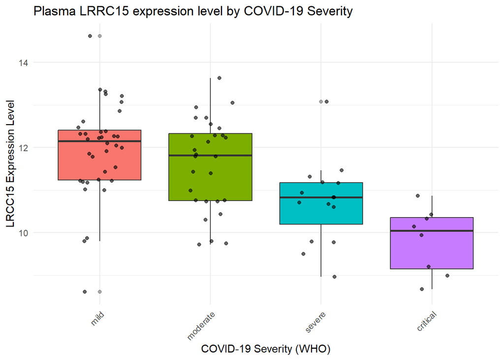

```r
#Boxplot (LRRC15 vs WHO_temp_severity):

LRRC15_data <- combined_mean %>%

 select(mean_LRRC15, WHO_temp_severity) %>%
 filter(WHO_temp_severity != "NEGATIVE") %>%   # Filter out NEGATIVE"

 mutate(

   WHO_temp_severity = factor(

     WHO_temp_severity,

     levels = c( "mild", "moderate", "severe", "critical")

   )

 )

ggplot(LRRC15_data, aes(x = WHO_temp_severity, y = mean_LRRC15, fill = WHO_temp_severity)) +

 geom_boxplot(outlier.alpha = 0.4) +

 geom_jitter(width = 0.2, alpha = 0.6) +

 labs(

   title = "Plasma LRRC15 expression level by COVID-19 Severity",

   x = "COVID-19 Severity (WHO)",

   y = "LRCC15 Expression Level"

 ) +

 theme_minimal() +

 theme(

   legend.position = "none",

   axis.text.x = element_text(angle = 45, hjust = 1)

 )
```

First impression : decreasing trend LRRC15 expression level as COVID-19 severity increases

One-way anova:

```r
# Filter out NEGATIVE category
combined_filtered <- subset(combined_mean, WHO_temp_severity != "NEGATIVE")

# One-way ANOVA on filtered data
anova_result <- aov(mean_LRRC15 ~ WHO_temp_severity, data = combined_filtered)
summary(anova_result)
```

```
##                   Df Sum Sq Mean Sq F value   Pr(>F)
## WHO_temp_severity  3  39.12  13.039    11.8 1.62e-06 ***
## Residuals         83  91.69   1.105
## ---
## Signif. codes:  0 '***' 0.001 '**' 0.01 '*' 0.05 '.' 0.1 ' ' 1
```

Result : There is a significant difference between at least 2 different severity groups (p-value = 1.62e-06 ) To know between which groups there is a significant difference a Post-hoc Tukey test can be done :

```r
# Post-hoc Tukey test
tukey_result <- TukeyHSD(anova_result)
tukey_result
```

```
##   Tukey multiple comparisons of means
##     95% family-wise confidence level
##
## Fit: aov(formula = mean_LRRC15 ~ WHO_temp_severity, data = combined_filtered)
##
## $WHO_temp_severity
##                         diff        lwr         upr     p adj
## mild-critical      2.1312433  1.0541394  3.20834713 0.0000087
## moderate-critical  1.7987687  0.6940423  2.90349505 0.0002984
## severe-critical    0.8979601 -0.3084661  2.10438637 0.2149374
## moderate-mild     -0.3324746 -1.0268386  0.36188940 0.5936983
## severe-mild       -1.2332832 -2.0801511 -0.38641523 0.0014495
## severe-moderate   -0.9008086 -1.7825415 -0.01907561 0.0433534
```

## 2.2 Multivariate hypothesis

Research question:Are lower LRRC15 levels, smoking, COPD and older age associated with case status?

hypothesis: Lower LRRC15 levels, smoking, COPD and older age are associated with a higher probability of being a case compared to a control.

### 2.2.1 Logistic regression model

Before Logistic regression model visualization of the LRRC15 levels between the different features of interest

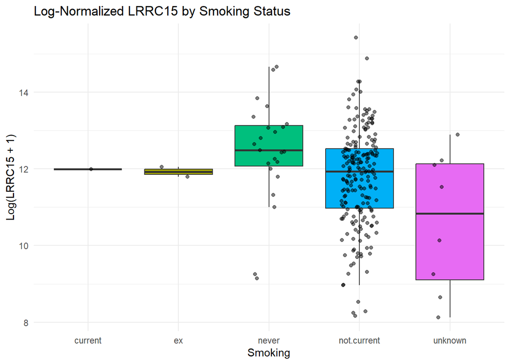

```r
# boxplots for features of interest
# bin age for boxplot
combined_log <- combined_log %>%
  mutate(age_group = cut(calc_age, breaks = seq(0, 100, by = 10),
                         labels = paste(seq(0, 90, by = 10), seq(10, 100, by = 10), sep = "-"),
                         right = FALSE))

# 1. LRRC15 vs Smoking
p1 <- ggplot(combined_log, aes(x = smoking, y = LRRC15, fill = smoking)) +
  geom_boxplot(outlier.shape = NA) +
  geom_jitter(width = 0.2, alpha = 0.5) +
  labs(title = "Log-Normalized LRRC15 by Smoking Status", x = "Smoking", y = "Log(LRRC15 + 1)") +
  theme_minimal() +
  theme(legend.position = "none")

# 2. LRRC15 vs COPD
p2 <- ggplot(combined_log, aes(x = copd, y = LRRC15, fill = copd)) +
  geom_boxplot(outlier.shape = NA) +
  geom_jitter(width = 0.2, alpha = 0.5) +
  labs(title = "Log-Normalized LRRC15 by COPD Status", x = "COPD", y = "Log(LRRC15 + 1)") +
  theme_minimal() +
  theme(legend.position = "none")

# 3. LRRC15 vs Age (binned)
p3 <- ggplot(combined_log, aes(x = age_group, y = LRRC15, fill = age_group)) +
  geom_boxplot(outlier.shape = NA) +
  geom_jitter(width = 0.2, alpha = 0.5) +
  labs(title = "Log-Normalized LRRC15 by Age Group", x = "Age Group", y = "Log(LRRC15 + 1)") +
  theme_minimal() +
  theme(legend.position = "none", axis.text.x = element_text(angle = 45, hjust = 1))

# Show plots
p1
```

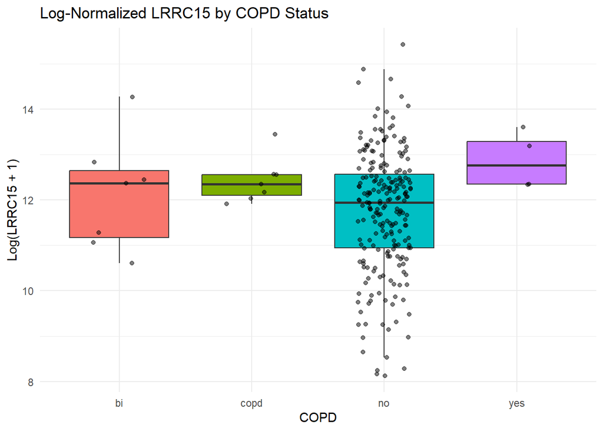

```r
p2
```

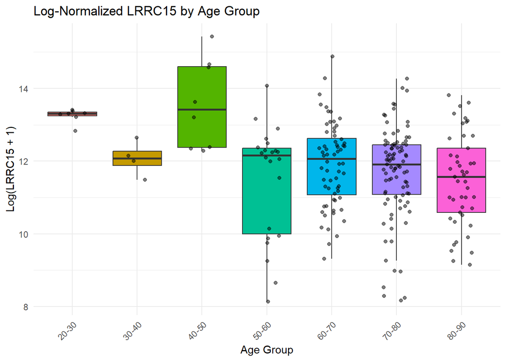

```r
p3
```

Recode case_control where NEGATIVE =0 and POSITIVE= 1

```r
# Show unique values
unique(combined_log$case_control)
```

```
## [1] "NEGATIVE" "POSITIVE"
```

```r
# Show frequencies from each value
table(combined_log$case_control)
```

```
##
## NEGATIVE POSITIVE
##       53      188
```

```r
# Recode case_control: POSITIVE -> 1, NEGATIVE -> 0
combined_log$case_control <- ifelse(combined_log$case_control == "POSITIVE", 1,
                                    ifelse(combined_log$case_control == "NEGATIVE", 0, NA))

# Check the result
table(combined_log$case_control, useNA = "ifany")
```

```
##
##   0   1
##  53 188
```

Possible correction for the multiple individual_IDs that are the same : Take last measurement of every individual_ID

```r
library(dplyr)

# For each individual_id take the last measurement
df_last <- combined_log %>%
  group_by(individual_id) %>%
  slice_tail(n = 1) %>%
  ungroup()

# check
df_last
```

```
## # A tibble: 91 × 7,260
##    X        CRYBB2  RAF1 ZNF41  ELK1 GUCA1A BECN1  OCRL SPDEF SNAI2 KCNAB2  POLH
##    <chr>     <dbl> <dbl> <dbl> <dbl>  <dbl> <dbl> <dbl> <dbl> <dbl>  <dbl> <dbl>
##  1 C101_po…   11.6  12.4  11.3  11.8   11.5  11.5  11.7  11.9  11.6   11.8  11.4
##  2 C103_ne…   11.8  11.3  11.9  12.1   12.0  11.9  12.4  11.7  11.7   11.8  12.0
##  3 C104_ne…   11.7  11.3  11.9  11.8   12.1  11.9  12.2  11.8  11.8   12.1  12.2
##  4 C106_ne…   11.8  11.0  11.9  11.9   12.1  12.5  12.7  11.9  12.3   12.3  11.9
##  5 C108_po…   11.5  12.4  11.3  11.7   11.5  11.5  11.8  11.7  11.7   12.0  11.4
##  6 C110_po…   11.7  11.3  11.6  11.9   11.8  11.9  12.2  11.8  11.7   11.6  11.9
##  7 C113_po…   11.7  10.8  11.9  11.9   11.9  12.1  11.8  11.7  11.9   11.7  11.9
##  8 C116_po…   11.9  11.0  11.7  11.8   11.9  11.9  12.5  11.5  11.9   11.7  11.9
##  9 C123_po…   11.9  11.1  12.0  11.8   11.9  11.8  12.1  11.7  11.8   11.8  12.0
## 10 C124_po…   11.9  11.1  11.8  12.7   12.1  11.9  12.1  11.8  11.8   11.8  11.9
## # ℹ 81 more rows
## # ℹ 7,248 more variables: VDR <dbl>, HOGA1 <dbl>, DLD <dbl>, MUTYH <dbl>,
## #   DUSP4 <dbl>, ZHX3 <dbl>, SIGLEC12 <dbl>, PNP <dbl>, TP63 <dbl>,
## #   HNF4A <dbl>, SGK3 <dbl>, BRD4 <dbl>, WNT10A <dbl>, CUL3 <dbl>, BIRC2 <dbl>,
## #   NCF2 <dbl>, CBFB <dbl>, TERF1 <dbl>, ILK <dbl>, GAN <dbl>, FOXM1 <dbl>,
## #   RAD23A <dbl>, FANCL <dbl>, RBBP9 <dbl>, PIN1 <dbl>, PLCG2 <dbl>,
## #   TDP1 <dbl>, BRD2 <dbl>, ACBD6 <dbl>, AP4M1 <dbl>, BAG3 <dbl>, …
```

Logistic regression model before the correction:

```r
# Logistic regression model wihtout correction
model_withoutcorrection <- glm(case_control ~ LRRC15 + smoking + copd + calc_age,
             data = combined_log,
             family = "binomial")

# Summary of the model
summary(model_withoutcorrection)
```

```
##
## Call:
## glm(formula = case_control ~ LRRC15 + smoking + copd + calc_age,
##     family = "binomial", data = combined_log)
##
## Coefficients:
##                      Estimate Std. Error z value Pr(>|z|)
## (Intercept)          40.12985 2399.54832   0.017   0.9867
## LRRC15               -1.66696    0.27341  -6.097 1.08e-09 ***
## smokingex           -32.86798 2935.83153  -0.011   0.9911
## smokingnever        -11.30050 2399.54498  -0.005   0.9962
## smokingnot.current  -14.74244 2399.54471  -0.006   0.9951
## smokingunknown      -16.20030 2399.54492  -0.007   0.9946
## copdcopd             -0.63965    1.80669  -0.354   0.7233
## copdno               -1.99759    1.43184  -1.395   0.1630
## copdyes              -0.36716    1.86211  -0.197   0.8437
## calc_age             -0.02871    0.01413  -2.032   0.0421 *
## ---
## Signif. codes:  0 '***' 0.001 '**' 0.01 '*' 0.05 '.' 0.1 ' ' 1
##
## (Dispersion parameter for binomial family taken to be 1)
##
##     Null deviance: 253.92  on 240  degrees of freedom
## Residual deviance: 169.75  on 231  degrees of freedom
## AIC: 189.75
##
## Number of Fisher Scoring iterations: 15
```

Logistic regression model after the correction:

```r
# Logistic regression model wihtout correction
model_withcorrection <- glm(case_control ~ LRRC15 +smoking + copd + calc_age,
             data = df_last,
             family = "binomial")

# Summary of the model
summary(model_withcorrection)
```

```
##
## Call:
## glm(formula = case_control ~ LRRC15 + smoking + copd + calc_age,
##     family = "binomial", data = df_last)
##
## Coefficients:
##                      Estimate Std. Error z value Pr(>|z|)
## (Intercept)         5.085e+01  5.595e+03   0.009    0.993
## LRRC15             -1.414e+00  3.587e-01  -3.943 8.05e-05 ***
## smokingex          -3.517e+01  4.843e+03  -0.007    0.994
## smokingnever       -1.370e+01  3.956e+03  -0.003    0.997
## smokingnot.current -1.698e+01  3.956e+03  -0.004    0.997
## smokingunknown     -1.772e+01  3.956e+03  -0.004    0.996
## copdcopd            1.025e+00  5.595e+03   0.000    1.000
## copdno             -1.608e+01  3.956e+03  -0.004    0.997
## copdyes            -1.548e+01  3.956e+03  -0.004    0.997
## calc_age           -4.623e-03  2.388e-02  -0.194    0.846
## ---
## Signif. codes:  0 '***' 0.001 '**' 0.01 '*' 0.05 '.' 0.1 ' ' 1
##
## (Dispersion parameter for binomial family taken to be 1)
##
##     Null deviance: 122.958  on 90  degrees of freedom
## Residual deviance:  82.406  on 81  degrees of freedom
## AIC: 102.41
##
## Number of Fisher Scoring iterations: 16
```

After the correction calc_age is no longer significant and only LRRC15 has a significant p-value

ODDS RATIO

```r
# calculation the odds ratios
odds = exp(coef(model_withcorrection))
odds
```

```
##        (Intercept)             LRRC15          smokingex       smokingnever
##       1.216735e+22       2.431094e-01       5.305042e-16       1.121436e-06
## smokingnot.current     smokingunknown           copdcopd             copdno
##       4.242919e-08       2.021908e-08       2.787811e+00       1.043258e-07
##            copdyes           calc_age
##       1.893130e-07       9.953875e-01
```

Result : Each 1-unit increase in LRRC15 reduces the odds of being a case by ~76%.